# 5 Module 2: Class 9/27

- Will review CLT statement
- Will look at what it means for Bernoulli example and using simulations

## 5.1 Example with Bernoulli distribution

- The Bernoulli is appealing because we can assess the CLT mathematically.
- Sum of Bernoulli RV is Binomial.
- Using the CLT, for samples $X_1, \ldots, X_n$, from this distribution the standardized mean is
  $$\sqrt{n}\frac{(\bar X_n -p)}{p(1-p)} \sim N(0,1) \text{ (approximately)}$$
- $\mathbb{P}(\sqrt{n} (\bar X - p)/\sqrt{p(1-p)} \le z) = \mathbb{P}\left(n\bar X \le \left(np(1-p)\right)^{1/2}\times z + np \right) \to \mathbb{P}(Z\le z)$, where $Z\sim N(0,1)$

So how do we evaluate this:

- Pick a value for $p$ and.
- Choose a vector for $n$ and $z$.
- Compare the CDFs by the sample size.

Note: We don’t even need to run simulations because we can do it using the CDFs in R.

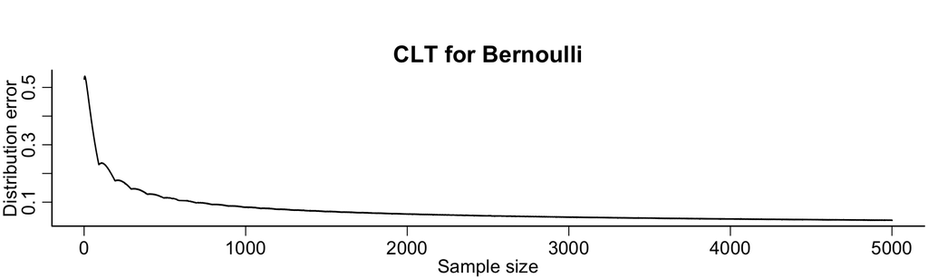

```r
ns = 1:5000
p = 0.01
z = seq(-2, 2, length.out=1000)

probDiffs = rep(NA, length(ns))
for(n in ns){
 probDiffs[n] = max(abs( pbinom(sqrt(n*p*(1-p))*z + n*p, size = n, prob=p) - pnorm(z)   )  )
}
plot(ns, probDiffs, xlab='Sample size', ylab='Distribution error', main='CLT for Bernoulli', type='l')
abline(h=0, lty=2)
```

## 5.2 QQ-plot!

## 5.3 Binomial proportion: Another look using simulations

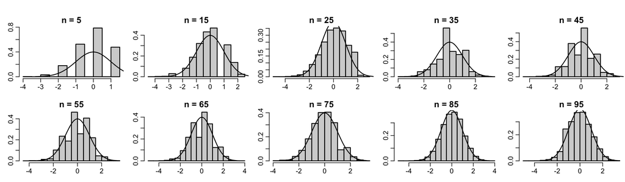

```r
ns = seq(5, 100, by=10)
layout(matrix(1:10, ncol=5, byrow=TRUE))
p = 0.75
for(n in ns){
  means = replicate(10000,
                 # compute mean 1000 times
                 sqrt(n) * (mean(rbinom(n, 1, p))-p) / sqrt(p*(1-p))
                 )
  hist(means,main=paste('n =', n), probability = TRUE, ylab='', xlab='' )
  # draw standard normal density
  x = qnorm(ppoints(1000))
  points(x, dnorm(x), type='l')
}
```

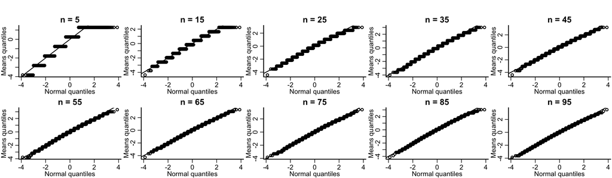

```r
layout(matrix(1:10, ncol=5, byrow=TRUE))
for(n in ns){
  means = replicate(10000,
                 # compute mean 1000 times
                 sqrt(n)*(mean(rbinom(n, 1, p))-p)/sqrt(p*(1-p))
                 )
  qqnorm(scale(means), main=paste('n =', n), ylab='Means quantiles', xlab='Normal quantiles' )
  abline(a=0, b=1)
}
```

## 5.4 Comment about dependence in the CLT

For a bunch of RVs with zero mean and nonzero covariance
$$\begin{aligned}
\text{Var}(n^{-1/2}\bar X_n) & = n^{-1}\text{Cov}(S_n, S_n) \\
& = \sum_{i,j}^n \text{Cov}(X_i, X_j) \\
& = n^{-1}\sum_{i=1}^n \text{Var}(X_i) + n^{-1}\sum_{i\ne j} \text{Cov}(X_j, X_k)\\
& = \text{Var}(X_i) + (n-1)\text{Cov}(X_j, X_k)\\
&\text{(if Var and Cov are the same for all RVs)}
\end{aligned}$$

Comments:

- The first term converges under CLT assumptions.
- The second term has $n(n-1)$ terms.
  - We need the covariance terms to get “small enough” for the CLT to work.
  - For example, by things that are “far away” having small covariance.

## 5.5 Conclusions of CLT

- The CLT allows us to make approximate probability statements for things that can be expressed as sums.
- This is handy when we don’t know the distribution of things.
- Some form of independence is necessary.

## 5.6 Take home points of LLN and CLT

- LLN is about the convergence of the mean estimator to a constant.
- CLT is about the convergence of the mean estimator times $\sqrt{n}$ to a normal distribution.
- CLT is used a lot in statistics to make approximate probability statements.